# Relationship between forearm length and height (.)

HS2440 (.)

September 26, 2020 (.)

## I. Introduction

Parts marked with (.) need updating. Part 1 (.)

This assignment is about using 10 randomly selected data points from the given sample a20a1data.csv to determine whether there is a relationship between forearm length and height.

The sample data was collected by using rulers to measure out the forearm length and height of the participants in centimeters.

I choose forearm length to be the response variable as it tends to vary with height. I choose height to be the explanatory variable since it explains changes and affects our response variable forearm length.

## II. Exploratory Data Analysis

The integers below are the IDs of the 10 randomly chosen observations by using the sample( ) function, these 10 observations are used as the sample data in this assignment.

```
##  [1] 304  72 113   6 208 252  57  64  73 279
```

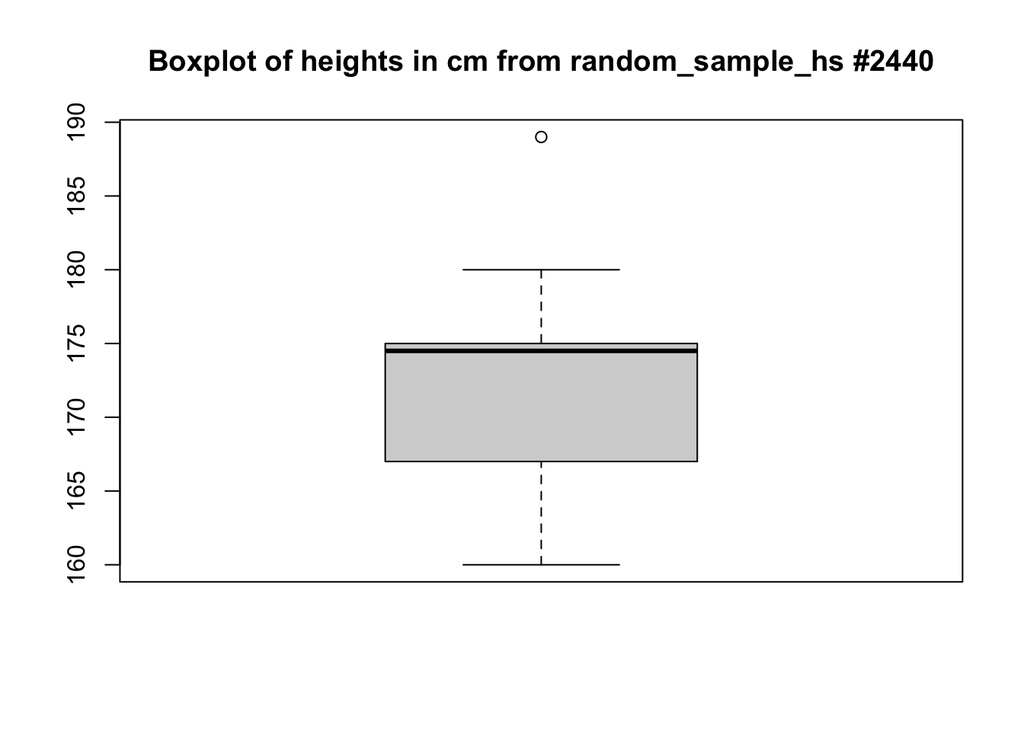

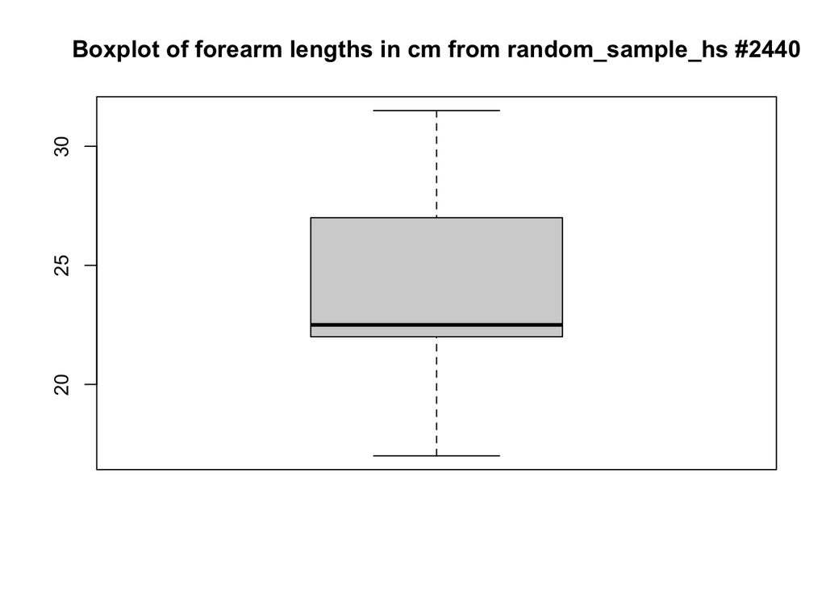

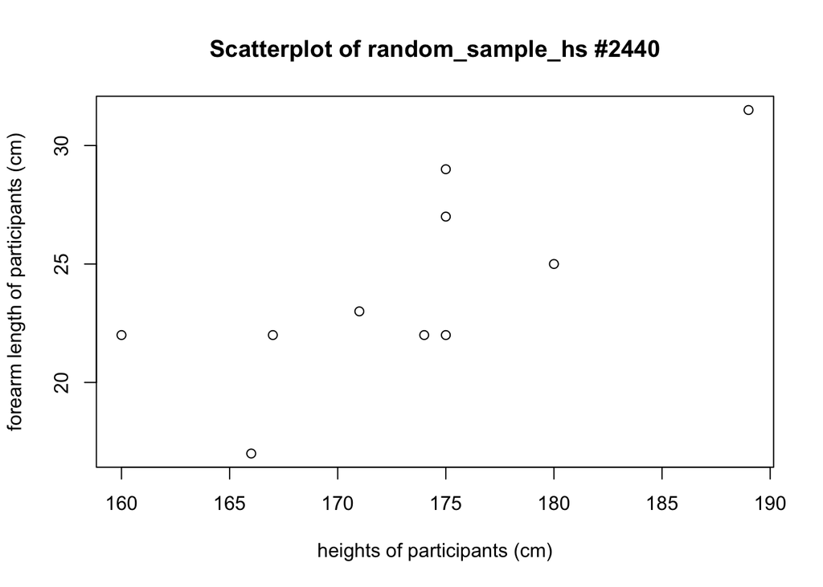

Part 2 (.) The random_sample_hs data is the set containing 10 randomly chosen data points from the “a20a1data” dataset.

The distribution of the response variable is right-skewed rather than being normal.

The explanatory variable height has a center of 174.5, a range of 29 cm, a variance of 64.0 and an outlier at 189 cm. The response variable forearm length has a center of 22.5, a range of 14.5, a variance of 17.5 and no outliers.

## III. Methods and Model

Part 3 (.)

```
##
## Call:
## lm(formula = random_sample_hs$forearm ~ random_sample_hs$height)
##
## Residuals:
##     Min      1Q  Median      3Q     Max
## -4.2243 -2.2027  0.0983  1.9950  4.2436
##
## Coefficients:
##                         Estimate Std. Error t value Pr(>|t|)
## (Intercept)             -43.9241    21.1554  -2.076   0.0715 .
## random_sample_hs$height   0.3925     0.1220   3.216   0.0123 *
## ---
## Signif. codes:  0 '***' 0.001 '**' 0.01 '*' 0.05 '.' 0.1 ' ' 1
##
## Residual standard error: 2.928 on 8 degrees of freedom
## Multiple R-squared:  0.5639, Adjusted R-squared:  0.5094
## F-statistic: 10.34 on 1 and 8 DF,  p-value: 0.01231
```

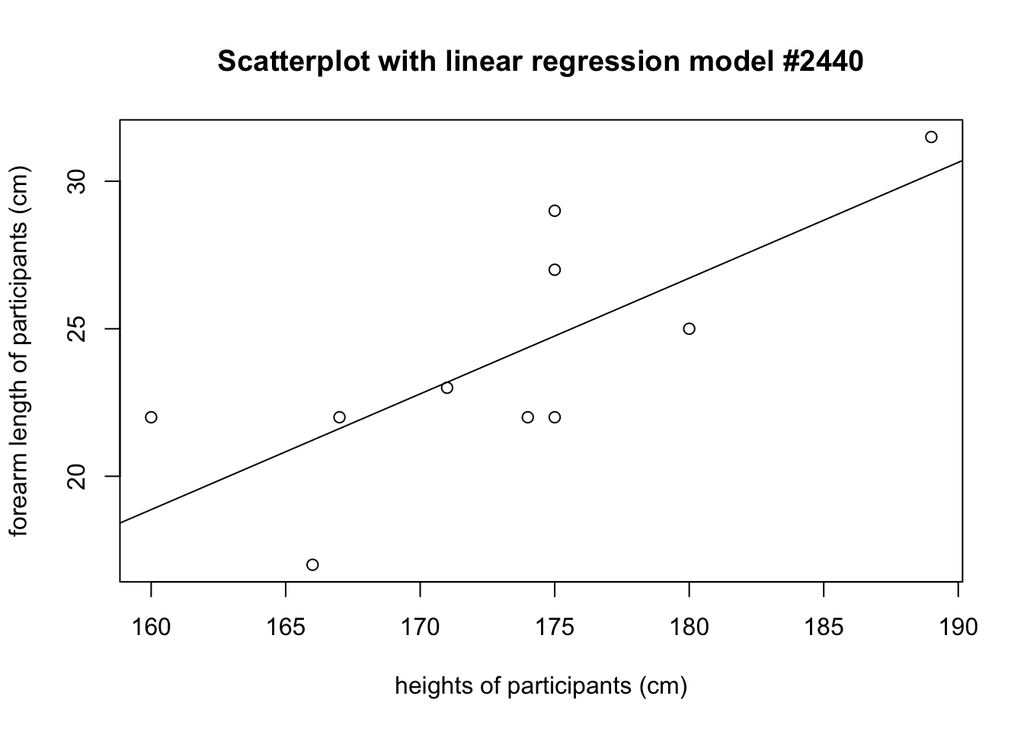

This linear regression model is produced by using forearm as y and heights as x. We acquired that this model has an intercept (B0) of -43.9 and a slope (B1) of 0.39. Hence the regression parameters are not zero.

The estimates of the regression parameters show that there is a positive correlation between heights and forearm lengths.The mean of forearm length increases by 0.39 cm whenever there is a 1 cm increase in height.

Additionally, the p-value of our independent variable is 0.0123, which is less than the benchmark significance level of 0.05. Thus the sample data provides enough evidence to reject the null hypothesis that height has no correlation with forearm length. In other words, the sample data favors the hypothesis that there is a non-zero correlation between height and forearm length.

## IV. Discussions and Limitations

Part 4 (.)

A lurking variable can be whether a person regularly does exercises involving the usage of forearm. One limitation of our fit is the relatively small sample size. With a bigger sample size, the data can represent the relationship between forearm length and height better. In addition, we also assumed their relationship is linear.

Example of another pair of variables that we can use SLR on is “Amount of alcohol consumed and blood alcohol content”, where blood alcohol content is the response variable.